# 4545 Team League: Season 10

[figure not shown]

### Overview

204 players participated, 81 (40%) of whom were new to the league.

26 teams played 104 matches over the season’s eight weeks. 18 matches (17%) were drawn, and 29 (28%) were won by just a single point.

In all, 580 games were played over the season. The season’s ‘unplayed pairing’ rate was 7.1%.[^1]

White won 263 games (45.4%), 102 games (17.6%) were drawn, and Black won 193 games (33.3%). The right-hand chart shows game results by colour for each board or average rating band.[^2]

[figure not shown]

### Final standings

*Team rosters ordered by number of games played (shown in brackets)*

1st place

[We’re OK with any name, actually](https://www.lichess4545.com/team4545/season/10/team/8/)

2nd place

[Make Luft not War](https://www.lichess4545.com/team4545/season/10/team/13/)

3rd place

[Octopus Knights](https://www.lichess4545.com/team4545/season/10/team/19/)

| Gold | Silver | Bronze |
| --- | --- | --- |
| dose7781 (8) | glbert (8) | Pedropablo72 (11) |
| MoistvonLipwig (8) | Hoikka (8) | paolone (9) |
| NarwhalePete (8) | LittleAnnieAdderall (8) | kleyveu (8) |
| PMyourPepes (8) | lovlas (8) | nimzovit (7) |
| rgpchesspe (8) | rampichino (8) | Alegre_River (6) |
| Heinie (5) | PsiMaster (7) | wargoblin (2) |
| AmoryRacingKing (1) |  | parametric (1) |
| Lord_axe (1) |  | TotalAnalysis (1) |

#### How the title race played out

[figure not shown]

**Match stories**

See the twists and turns in every match this season through these PDF visualisations…assuming they’ve already been created and uploaded. [Source script](https://github.com/rahulan-c/lichess4545-stats/blob/main/scripts/plot_match_story.R).

Round 1 | Round 2 | Round 3 | Round 4 | Round 5 | Round 6 | Round 7 | Round 8

### Top players 🎩

#### Board medals

Here are the top player performances on each board (minimum 5 games played).[^3]

| Board | Player(s) | Games | Points | Board Perf. |
| --- | --- | --- | --- | --- |
| 1 | lovlas | 8 | 7.5 | 2664.875 |
| 1 | Sonata2 | 7 | 5 | 2350.42857142857 |
| 1 | ErinYu | 6 | 4.5 | 2349.83333333333 |
| 2 | Alegre_River | 5 | 4 | 2225 |
| 2 | GnarlyGoat | 6 | 5 | 2224.66666666667 |
| 2 | hawkins89 | 6 | 4.5 | 2174.16666666667 |
| 3 | chennis | 5 | 3.5 | 2053 |
| 3 | GCEDW2001 | 6 | 4 | 2015 |
| 3 | shetoo | 6 | 3.5 | 1949.83333333333 |
| 4 | krispl | 5 | 4 | 2008.2 |

[output cut: 8 more lines]

#### Best scorers

Here’s everyone who achieved a plus score of +5 or higher this season[^4]:

**jkobs** (7.5/8), **lovlas** (7.5/8), **deep_glue** (7/8), **Glaisepapale** (6/6), **david-innes** (7/9), **PsiMaster** (6/7)

Players with plus scores of +6 or better get the **Ace** award.

### Stats - overview

#### Timing 📊

[figure not shown]

#### Length 📊

[figure not shown]

#### Most moves

*Includes games ranked at or above the 90th percentile by number of moves.*

| Rank | Players / Link | Date | Moves |
| --- | --- | --- | --- |
| 1 | mariuseg - CamelClutcher | Wed 29 Nov 2017 | 117 |
| 2 | Kolnikov - Toffeeman | Sun 10 Dec 2017 | 94 |
| 2 | MelodyMarathon - supermaths | Tue 28 Nov 2017 | 94 |
| 3 | dinomoomoo - SpiteKnight | Wed 13 Dec 2017 | 84 |
| 3 | GogoYubari - pioki | Fri 19 Jan 2018 | 84 |
| 4 | hsznet - Benedictine | Sun 14 Jan 2018 | 83 |
| 5 | morallygray - mariuseg | Thu 28 Dec 2017 | 82 |
| 6 | TCGRIF - qrs | Sat 9 Dec 2017 | 81 |
| 7 | MasterSalomon - yago666 | Wed 6 Dec 2017 | 80 |
| 7 | fisher56 - lemonworld | Sat 20 Jan 2018 | 80 |

[output cut: 45 more lines]

#### Longest games

*Includes games ranked at or above the 90th percentile by total clock time.*[^5]

| Rank | Players / Link | Date | Total time |
| --- | --- | --- | --- |
| 1 | morallygray - mariuseg | Thu 28 Dec 2017 | 3h 21m 24s |
| 2 | mariuseg - CamelClutcher | Wed 29 Nov 2017 | 3h 19m 36s |
| 3 | yago666 - hawkins89 | Sun 17 Dec 2017 | 3h 15m 43s |
| 4 | fisher56 - lemonworld | Sat 20 Jan 2018 | 3h 12m 22s |
| 5 | MelodyMarathon - supermaths | Tue 28 Nov 2017 | 3h 11m 55s |
| 6 | quirked - revoof | Fri 22 Dec 2017 | 3h 11m 22s |
| 7 | colwem - Nairwolf | Thu 18 Jan 2018 | 3h 5m 55s |
| 8 | TheRatRiverTrapper - DirtyJs | Sun 21 Jan 2018 | 3h 5m 39s |
| 9 | TCGRIF - qrs | Sat 9 Dec 2017 | 3h 1m 37s |
| 10 | Kolnikov - Toffeeman | Sun 10 Dec 2017 | 3h 1m 15s |

[output cut: 45 more lines]

### Stats - by board/rating

#### ACPL and blunder rate 📊

[figure not shown]

#### Lowest combined ACPL

The games with the lowest combined ACPL (including draws).

| Board | Players / Link | Result | Sum ACPL | Date |
| --- | --- | --- | --- | --- |
| 1 | ErinYu - lovlas | 1/2-1/2 | 8 | Sun 3 Dec 2017 |
| 2 | somethingpretentious - liamvo | 1/2-1/2 | 20 | Sun 14 Jan 2018 |
| 3 | LeDarkKnight - arsenalfanrichi | 1/2-1/2 | 14 | Sun 21 Jan 2018 |
| 4 | Seb32 - superposition | 0-1 | 15 | Sun 14 Jan 2018 |
| 5 | Kolnikov - Lukhas | 1/2-1/2 | 32 | Wed 22 Nov 2017 |
| 6 | gm1224 - Kraaft | 1/2-1/2 | 29 | Fri 8 Dec 2017 |

#### Decisive games only

The *decisive* games with the lowest combined ACPL.

| Board | Players / Link | Result | Sum ACPL | Date |
| --- | --- | --- | --- | --- |
| 1 | supermaths - Keresch | 1-0 | 22 | Thu 7 Dec 2017 |
| 2 | liamvo - LittleAnnieAdderall | 1-0 | 35 | Thu 23 Nov 2017 |
| 3 | Keresch - EinarGregersen | 0-1 | 31 | Thu 4 Jan 2018 |
| 4 | Seb32 - superposition | 0-1 | 15 | Sun 14 Jan 2018 |
| 5 | deep_glue - TCGRIF | 1-0 | 38 | Thu 30 Nov 2017 |
| 6 | michionov - Kraaft | 0-1 | 36 | Wed 10 Jan 2018 |

### Openings

#### First moves 📊

[figure not shown]

#### Top openings

All openings played in the season, excluding variations.

| rank | opening.broad | games | perc_w | white_wins | draws | black_wins | mean_eval_after_15 | mean_rating |
| --- | --- | --- | --- | --- | --- | --- | --- | --- |
| 1 | Sicilian Defense | 68 | 61.0294117647059 | 51.4705882352941 | 19.1176470588235 | 29.4117647058824 | 0.505970149253731 | 1849.79411764706 |
| 2 | English Opening | 46 | 63.0434782608696 | 56.5217391304348 | 13.0434782608696 | 30.4347826086957 | 0.271777777777778 | 1856.75 |
| 3 | French Defense | 37 | 60.8108108108108 | 51.3513513513513 | 18.9189189189189 | 29.7297297297297 | 0.298918918918919 | 1838.14864864865 |
| 4 | Queen's Pawn Game | 35 | 47.1428571428571 | 40 | 14.2857142857143 | 45.7142857142857 | 0.222571428571429 | 1709.07142857143 |
| 5 | Queen's Gambit Declined | 33 | 59.0909090909091 | 48.4848484848485 | 21.2121212121212 | 30.3030303030303 | 0.463939393939394 | 1873.13636363636 |
| 6 | Caro-Kann Defense | 28 | 50 | 39.2857142857143 | 21.4285714285714 | 39.2857142857143 | 0.395357142857143 | 1776.26785714286 |
| 7 | Ruy Lopez | 26 | 48.0769230769231 | 38.4615384615385 | 19.2307692307692 | 42.3076923076923 | 0.6416 | 1769 |
| 8 | Slav Defense | 25 | 54 | 40 | 28 | 32 | 0.356 | 1884.02 |
| 9 | King's Indian Defense | 23 | 52.1739130434783 | 43.4782608695652 | 17.3913043478261 | 39.1304347826087 | 0.500869565217391 | 1772.91304347826 |
| 10 | Italian Game | 19 | 68.4210526315789 | 63.1578947368421 | 10.5263157894737 | 26.3157894736842 | 0.738333333333333 | 1786.31578947368 |

[output cut: 51 more lines]

#### Best for White

White’s top-scoring openings, excluding variations. *Minimum 10 games played.*

| rank | opening.broad | games | perc_w | white_wins | draws | black_wins | mean_eval_after_15 | mean_rating |
| --- | --- | --- | --- | --- | --- | --- | --- | --- |
| 1 | Italian Game | 19 | 68.4210526315789 | 63.1578947368421 | 10.5263157894737 | 26.3157894736842 | 0.738333333333333 | 1786.31578947368 |
| 2 | Indian Defense | 18 | 63.8888888888889 | 61.1111111111111 | 5.55555555555556 | 33.3333333333333 | 0.649444444444444 | 1822.27777777778 |
| 3 | Scandinavian Defense | 19 | 63.1578947368421 | 52.6315789473684 | 21.0526315789474 | 26.3157894736842 | 0.463684210526316 | 1766.92105263158 |
| 4 | English Opening | 46 | 63.0434782608696 | 56.5217391304348 | 13.0434782608696 | 30.4347826086957 | 0.271777777777778 | 1856.75 |
| 5 | Sicilian Defense | 68 | 61.0294117647059 | 51.4705882352941 | 19.1176470588235 | 29.4117647058824 | 0.505970149253731 | 1849.79411764706 |
| 6 | French Defense | 37 | 60.8108108108108 | 51.3513513513513 | 18.9189189189189 | 29.7297297297297 | 0.298918918918919 | 1838.14864864865 |
| 7 | Queen's Gambit Declined | 33 | 59.0909090909091 | 48.4848484848485 | 21.2121212121212 | 30.3030303030303 | 0.463939393939394 | 1873.13636363636 |
| 8 | Scotch Game | 12 | 58.3333333333333 | 50 | 16.6666666666667 | 33.3333333333333 | 0.364545454545455 | 1697.375 |
| 9 | Nimzo-Indian Defense | 15 | 56.6666666666667 | 46.6666666666667 | 20 | 33.3333333333333 | 0.580666666666667 | 1952.73333333333 |
| 9 | Pirc Defense | 15 | 56.6666666666667 | 40 | 33.3333333333333 | 26.6666666666667 | 0.282666666666667 | 1878.83333333333 |

[output cut: 7 more lines]

#### Best for Black

Black’s top-scoring openings, excluding variations. *Minimum 10 games played.*

| rank | opening.broad | games | perc_b | black_wins | draws | white_wins | mean_eval_after_15 | mean_rating |
| --- | --- | --- | --- | --- | --- | --- | --- | --- |
| 1 | Dutch Defense | 18 | 61.1111111111111 | 55.5555555555556 | 11.1111111111111 | 33.3333333333333 | 0.289444444444444 | 1839.5 |
| 2 | Queen's Pawn Game | 35 | 52.8571428571429 | 45.7142857142857 | 14.2857142857143 | 40 | 0.222571428571429 | 1709.07142857143 |
| 3 | Ruy Lopez | 26 | 51.9230769230769 | 42.3076923076923 | 19.2307692307692 | 38.4615384615385 | 0.6416 | 1769 |
| 4 | Caro-Kann Defense | 28 | 50 | 39.2857142857143 | 21.4285714285714 | 39.2857142857143 | 0.395357142857143 | 1776.26785714286 |
| 5 | King's Indian Defense | 23 | 47.8260869565217 | 39.1304347826087 | 17.3913043478261 | 43.4782608695652 | 0.500869565217391 | 1772.91304347826 |
| 6 | Benoni Defense | 15 | 46.6666666666667 | 40 | 13.3333333333333 | 46.6666666666667 | 0.586666666666667 | 1923 |
| 7 | Slav Defense | 25 | 46 | 32 | 28 | 40 | 0.356 | 1884.02 |
| 8 | Nimzo-Indian Defense | 15 | 43.3333333333333 | 33.3333333333333 | 20 | 46.6666666666667 | 0.580666666666667 | 1952.73333333333 |
| 8 | Pirc Defense | 15 | 43.3333333333333 | 26.6666666666667 | 33.3333333333333 | 40 | 0.282666666666667 | 1878.83333333333 |
| 9 | Scotch Game | 12 | 41.6666666666667 | 33.3333333333333 | 16.6666666666667 | 50 | 0.364545454545455 | 1697.375 |

[output cut: 7 more lines]

#### Top gambits

The most played gambits over the season.[^6]

| Rank | Name | Games | White score (%) |
| --- | --- | --- | --- |
| 1 | Benko Gambit | 8 | 0.375 |
| 2 | Scotch Gambit | 6 | 0.333333333333333 |
| 3 | Smith-Morra Gambit | 5 | 0.6 |
| 4 | Queen's Gambit Accepted | 3 | 0.833333333333333 |
| 5 | Greco Gambit | 2 | 0.5 |
| 5 | King's Gambit | 2 | 0.5 |
| 6 | Budapest Defense | 2 | 0 |
| 7 | Evans Gambit | 1 | 1 |
| 7 | From's Gambit | 1 | 1 |
| 7 | Krejcik Gambit | 1 | 1 |

[output cut: 17 more lines]

#### Gambiteers 🤺

The players who enjoyed the most success when playing gambits.[^7] *Includes everyone who scored at least 50 per cent across at least two gambit games.*

| Rank | Player | Games | % Score | W | B | Choices |
| --- | --- | --- | --- | --- | --- | --- |
| 1 | david-innes | 3 | 83.3333333333333 | 2 | 1 | Ross Gambit, Danish Gambit, von der Lasa Gambit |
| 2 | Michael_Hackett | 3 | 66.6666666666667 | 2 | 1 | Smith-Morra Gambit, Scotch Gambit, Benko Gambit |
| 3 | TCGRIF | 2 | 100 | 2 | 0 | King's Gambit, Evans Gambit |
| 4 | TheRatRiverTrapper | 2 | 75 | 1 | 1 | Smith-Morra Gambit, Blumenfeld Countergambit |
| 5 | Davbond | 2 | 50 | 2 | 0 | Double Gambit, Scotch Gambit |
| 5 | LittleAnnieAdderall | 2 | 50 | 0 | 2 | Benko Gambit |

### Openings sunburst 🌞

Click on the image below to see a sunburst plot of all openings played in the season.

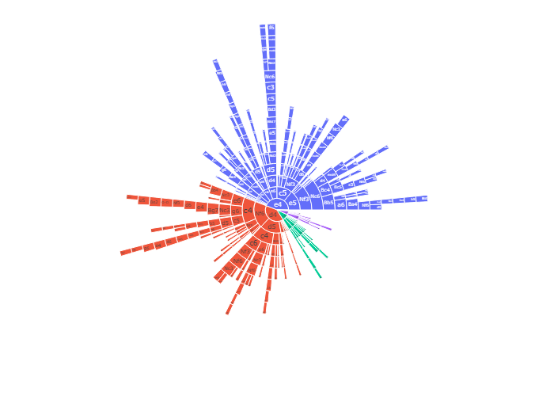

### Awards 🏆

Assorted awards to celebrate the season. See the footnote for more details about each award.[^8]

| Award | Name / Description | Winner(s) | Runner(s)-up |
| --- | --- | --- | --- |
| x | Aces | deep_glue, Glaisepapale, jkobs, lovlas |  |
| x | Archbishop of Accuracy | jkobs | lovlas, davejishnu |
| x | Awesome Alt | pioki, Scrooge | arsenalfanrichi, ChessHavoc, dimitris22, Lord_axe, OscarArnoux, Staincastle, superposition, TMax (3) |
| x | Bullet Boss | InfernalJumble | davejishnu, tipau |
| x | David Award | SolarNight | NarwhalePete, rederik79 |
| x | Egalitarian Award | Knights Radiant |  |
| x | Gambit Guru | david-innes | Michael_Hackett, TCGRIF |
| x | Giri Award | Bjorgvin1, mariuseg, roso97 |  |
| x | Grischuk's Cousin | Kraaft | MoistvonLipwig, kleyveu |
| x | Houdini Award | Kolnikov | Glaisepapale, glbert |

[output cut: 10 more lines]

- Fortune favoured **Are you KIDding me?**, who managed to win **3** matches by a single point!
- Conversely, **Sic Semper Tyrannis** must be ruing their luck after suffering **3** agonising single-point defeats.

### Stats - tables 📚

Tons of detailed stats for your reading pleasure. All tables in this section are sortable and searchable - feel free to explore!

#### Team statistics

Check out various team stats in the table below. Hover over the abbreviated headers to see their full names.

| rank | Team | games | points | pts_nonforf | wins | draws | losses | players | avg_moves | ACPL | blunder_pc |
| --- | --- | --- | --- | --- | --- | --- | --- | --- | --- | --- | --- |
| 1 | We're OK with any name, actually | 47 | 32.5 | 31.5 | 27 | 9 | 11 | 8 | 40.2978723404255 | 37.2914466737064 | 2.85110876451954 |
| 2 | Make Luft not War | 47 | 32 | 30.5 | 28 | 5 | 14 | 6 | 42.5744680851064 | 39.7966016991504 | 2.4487756121939 |
| 3 | Octopus Knights | 45 | 28 | 23.5 | 19 | 9 | 17 | 8 | 41.3111111111111 | 36.3528778913394 | 3.4965034965035 |
| 4 | Who Keres? | 44 | 25.5 | 23.5 | 21 | 5 | 18 | 10 | 38.6818181818182 | 39.0146886016451 | 3.70152761457109 |
| 5 | Do You Even Rook Lift, Bro? | 47 | 30.5 | 29.5 | 24 | 11 | 12 | 8 | 41.1276595744681 | 39.9943093636834 | 3.67304707708226 |
| 6 | In It For The Groupies | 44 | 28.5 | 26.5 | 24 | 5 | 15 | 9 | 41.0227272727273 | 36.0969529085873 | 2.54847645429363 |
| 7 | Knights Radiant | 46 | 26 | 23 | 19 | 8 | 19 | 6 | 40.5869565217391 | 44.570433851098 | 4.01713979646492 |
| 8 | The Kingpins | 45 | 25.5 | 22.5 | 17 | 11 | 17 | 11 | 41.8222222222222 | 43.0967056323061 | 4.19766206163656 |
| 9 | Zugzwang Zombies | 45 | 25.5 | 24.5 | 20 | 9 | 16 | 9 | 41.5555555555556 | 41.1032085561497 | 3.63636363636364 |
| 10 | The Amazing Maurice and his Educated Magnuses | 46 | 25 | 21 | 15 | 12 | 19 | 10 | 39.0217391304348 | 39.0350974930362 | 3.3983286908078 |

[output cut: 16 more lines]

#### Best performances / highest accuracy

##### Best relative performances

This table shows players’ *relative* performance ratings – that is, their performance rating over the season minus their initial rating before their first game.[^9] *Includes everyone with a positive relative performance rating over at least five games.*

| # | Player | Games | W | D | L | Initial | Perf | Diff. |
| --- | --- | --- | --- | --- | --- | --- | --- | --- |
| 1 | Glaisepapale | 6 | 6 | 0 | 0 | 1527 | 2311.66666666667 | 784.666666666667 |
| 2 | jkobs | 8 | 7 | 1 | 0 | 1745 | 2311.25 | 566.25 |
| 3 | hawkins89 | 6 | 4 | 1 | 1 | 1811 | 2174.16666666667 | 363.166666666667 |
| 4 | deep_glue | 8 | 7 | 0 | 1 | 1688 | 2000.875 | 312.875 |
| 5 | davejishnu | 8 | 5 | 2 | 1 | 1665 | 1960.875 | 295.875 |
| 6 | lovlas | 8 | 7 | 1 | 0 | 2392 | 2664.875 | 272.875 |
| 7 | colwem | 7 | 5 | 1 | 1 | 1466 | 1718 | 252 |
| 8 | archone | 7 | 4 | 2 | 1 | 1937 | 2174.14285714286 | 237.142857142857 |
| 9 | Arkensiel | 6 | 3 | 0 | 3 | 1259 | 1489 | 230 |
| 10 | LittleAnnieAdderall | 7 | 5 | 0 | 2 | 1921 | 2150.42857142857 | 229.428571428572 |

[output cut: 67 more lines]

##### Lowest ACPL

All players who played at least five games and achieved a season ACPL in the 20th percentile or below. Note that ‘season ACPL’ differs from Lichess game-wide ACPL figures, as it excludes opening moves as well as most moves played in objectively decided positions. See the footnote for full details.[^10] ACPLs based on Lichess’s published figures are provided for comparison purposes.

| Rank | Player | Games | Season ACPL | Lichess ACPL |
| --- | --- | --- | --- | --- |
| 1 | jkobs | 8 | 23.2147239263804 | 21.6588235294118 |
| 2 | lovlas | 8 | 26.6875 | 19.1672862453532 |
| 3 | davejishnu | 8 | 27.9946808510638 | 23.8284023668639 |
| 4 | god666 | 8 | 29.5769230769231 | 21.1529411764706 |
| 5 | ErinYu | 6 | 29.6176470588235 | 21.5091575091575 |
| 6 | supermaths | 7 | 29.8545454545455 | 22.3754385964912 |
| 7 | CamelClutcher | 6 | 30.5746268656716 | 27.3248175182482 |
| 8 | hawkins89 | 6 | 31.56 | 26.1141868512111 |
| 9 | MoistvonLipwig | 8 | 35.8380281690141 | 28.6644295302013 |
| 10 | Scrooge | 5 | 36.0309278350515 | 29.4692737430168 |

[output cut: 30 more lines]

#### Time spent / strongest opponents

##### Time spent

The 50 players who spent the most clock time over the season.

| Rank | Player | Games | Total time spent |
| --- | --- | --- | --- |
| 1 | mariuseg | 8 | 11h 53m 38s |
| 2 | Kraaft | 10 | 11h 2m 47s |
| 3 | GnarlyGoat | 8 | 9h 49m 52s |
| 4 | InfernalJumble | 8 | 9h 46m 36s |
| 5 | gucelli | 9 | 9h 41m 40s |
| 6 | morallygray | 9 | 9h 36m 2s |
| 7 | JohnsonBronson | 8 | 9h 15m 16s |
| 8 | roso97 | 8 | 9h 12m 5s |
| 9 | TheRatRiverTrapper | 7 | 9h 6m 3s |
| 10 | glbert | 8 | 9h 3m 46s |

[output cut: 40 more lines]

##### Time spent per move (after move 10)

Minimum 3 games played.

| Rank | Player | Games | Moves | Time spent per move | Percentile |
| --- | --- | --- | --- | --- | --- |
| 1 | shetoo | 6 | 173 | 2m 10.3s | 100 |
| 2 | LuvGangster | 7 | 142 | 2m 4.4s | 99 |
| 3 | superposition | 4 | 62 | 2m 3.8s | 98 |
| 4 | Sonata2 | 6 | 113 | 2m 1.6s | 97 |
| 5 | Scrooge | 5 | 129 | 1m 56.9s | 96 |
| 6 | archone | 7 | 203 | 1m 56.0s | 95 |
| 7 | ErinYu | 6 | 213 | 1m 54.2s | 94 |
| 8 | Star-Bearer | 7 | 143 | 1m 53.8s | 93 |
| 9 | myle | 5 | 127 | 1m 53.6s | 92 |
| 10 | EinarGregersen | 8 | 199 | 1m 53.4s | 91 |

[output cut: 141 more lines]

##### Strength of schedule

The players who faced the best-scoring opponents over the season, when judged by their collective score over all their *other* games. *Suggested by Tranzoo.*

| # | Player | Opp Games | Opp Pts | Opp % |
| --- | --- | --- | --- | --- |
| 1 | SolarNight | 37 | 25 | 67.5675675675676 |
| 2 | NarwhalePete | 41 | 27.5 | 67.0731707317073 |
| 3 | rederik79 | 21 | 14 | 66.6666666666667 |
| 4 | lovlas | 45 | 29 | 64.4444444444444 |
| 5 | Heinie | 28 | 18 | 64.2857142857143 |
| 6 | TCGRIF | 41 | 26 | 63.4146341463415 |
| 7 | Nairwolf | 38 | 24 | 63.1578947368421 |
| 8 | ErinYu | 37 | 23 | 62.1621621621622 |
| 9 | SamuelIFowler | 21 | 13 | 61.9047619047619 |
| 10 | Assassin_in_White | 34 | 21 | 61.7647058823529 |

[output cut: 60 more lines]

#### Comebacks and upsets

##### Comebacks

The players who achieved the most significant comeback wins and draws over the season.[^11] *Suggested by Lou-E.*

| Rank | Player | CB Games | Wins from < -6 | Wins from < -3 | Draws from < -6 | Draws from < -3 |
| --- | --- | --- | --- | --- | --- | --- |
| 1 | Kolnikov | 3 | 2 | 1 | 0 | 0 |
| 2 | Glaisepapale | 3 | 1 | 2 | 0 | 0 |
| 3 | glbert | 3 | 2 | 0 | 0 | 1 |
| 4 | deanmadden | 3 | 1 | 1 | 0 | 1 |
| 4 | Poseh | 2 | 2 | 0 | 0 | 0 |
| 4 | timoru | 2 | 2 | 0 | 0 | 0 |
| 5 | Arkensiel | 2 | 1 | 1 | 0 | 0 |
| 5 | LuvGangster | 2 | 1 | 1 | 0 | 0 |
| 5 | omoueza | 2 | 1 | 1 | 0 | 0 |
| 6 | bornacavrag | 2 | 1 | 0 | 1 | 0 |

[output cut: 81 more lines]

##### Biggest upsets

Everyone who defeated an opponent who outrated them by at least 100 points.

| Rank | Player | Upset Margin | Link |
| --- | --- | --- | --- |
| 1 | kart0ffelsalaat | 349 | https://lichess.org/1sBnhOxD |
| 2 | david-innes | 308 | https://lichess.org/Bf8mhai2 |
| 3 | Arkensiel | 289 | https://lichess.org/C3AJuysf |
| 4 | Lelouch_Vi_Brittania | 256 | https://lichess.org/1j3syMgv |
| 5 | Arkensiel | 255 | https://lichess.org/G0dVS2uW |
| 6 | Boomer34 | 250 | https://lichess.org/UX5sifOk |
| 7 | bornacavrag | 226 | https://lichess.org/tWaCeW44 |
| 7 | Kolnikov | 226 | https://lichess.org/piYm8bMD |
| 8 | LuvGangster | 220 | https://lichess.org/fqWlDqFl |
| 9 | dimitris22 | 219 | https://lichess.org/NDOUZxE1 |

[output cut: 39 more lines]

##### Repeated upsets

Everyone who achieved multiple wins over opponents rated at least 50 points higher.

| Rank | Player | Total Upset Margin | Upsets | Avg Upset Margin | Biggest Margin |
| --- | --- | --- | --- | --- | --- |
| 1 | Arkensiel | 696 | 3 | 232 | 289 |
| 2 | bornacavrag | 450 | 3 | 150 | 226 |
| 3 | Boomer34 | 427 | 2 | 213.5 | 250 |
| 4 | Lelouch_Vi_Brittania | 378 | 2 | 189 | 256 |
| 5 | MasterSalomon | 327 | 2 | 163.5 | 181 |
| 6 | rhohit | 301 | 2 | 150.5 | 156 |
| 7 | archone | 255 | 2 | 127.5 | 154 |

#### Dawdlers and instant movers

##### Least time left after move 10

Players who had the least time left after only 10 moves…but still managed to win! *Suggested by Silkthewanderer.*

| Rank | Player | Time left after 10 moves | Link |
| --- | --- | --- | --- |
| 1 | Kraaft | 15m 42s | https://lichess.org/d5WXvY6X#19 |
| 2 | MoistvonLipwig | 15m 51s | https://lichess.org/ACoUnkAh#19 |
| 3 | kleyveu | 17m 23s | https://lichess.org/dvEZseZT#19 |
| 4 | rkjulian | 19m 19s | https://lichess.org/nHHABldl#20 |
| 5 | RodrigoDiazdeVivar | 20m 19s | https://lichess.org/ZXzHLKs2#20 |
| 6 | JohnsonBronson | 20m 20s | https://lichess.org/crdy9tdN#20 |
| 7 | novemberyankee | 20m 32s | https://lichess.org/CZPcAH2F#19 |
| 8 | rkjulian | 21m 36s | https://lichess.org/e93zWLVT#19 |
| 9 | Seb32 | 21m 50s | https://lichess.org/NFS2WoOK#19 |
| 10 | archone | 21m 53s | https://lichess.org/cZibeJcM#19 |

##### Instant moves

Players who made at least five ‘instant’ moves (in under 0.5s), including pre-moves.

| Rank | Player | Instant moves |
| --- | --- | --- |
| 1 | InfernalJumble | 20 |
| 2 | davejishnu | 17 |
| 2 | tipau | 17 |
| 3 | lovlas | 15 |
| 4 | MarionTinsley | 14 |
| 4 | roso97 | 14 |
| 5 | Axp156 | 13 |
| 5 | FlokiTheCat | 13 |
| 5 | GnarlyGoat | 13 |
| 6 | Asinya | 12 |

[output cut: 35 more lines]

#### Longest thinks, time trouble addicts, and lucky escapes

##### Longest thinks

The longest times spent on a single move.

*Top 100 shown.*

| # | Player | Time spent | Colour | Move | Link |
| --- | --- | --- | --- | --- | --- |
| 1 | AlwxR | 43m 35s | Black | 9 | https://lichess.org/SKjk9Ve7#18 |
| 2 | Forhavu | 33m 54s | Black | 19 | https://lichess.org/G0dVS2uW#38 |
| 3 | philgood84 | 32m 18s | White | 26 | https://lichess.org/yTsnWZkG#51 |
| 4 | DirtyJs | 27m 53s | Black | 60 | https://lichess.org/OGtpclgj#120 |
| 5 | MarionTinsley | 26m 15s | White | 17 | https://lichess.org/dIx1ju9k#33 |
| 6 | novemberyankee | 23m 50s | White | 10 | https://lichess.org/CZPcAH2F#19 |
| 7 | supermaths | 23m 41s | Black | 28 | https://lichess.org/i80igIem#56 |
| 8 | Keresch | 21m 59s | White | 18 | https://lichess.org/GCfxxMRG#35 |
| 9 | Bjorgvin1 | 20m 57s | White | 22 | https://lichess.org/jBUW3veV#43 |
| 10 | Asinya | 20m 31s | White | 23 | https://lichess.org/519ohdb9#45 |

[output cut: 90 more lines]

##### Time trouble addicts

Shows players by proportion of moves made in time trouble (defined as having less than a minute remaining on the clock). Includes everyone who played at least 100 moves over the season while making at least one move in time trouble.

| # | Player | All moves | With < 1min left | Time Trouble % |
| --- | --- | --- | --- | --- |
| 1 | SolarNight | 292 | 48 | 0.164383561643836 |
| 2 | Lelouch_Vi_Brittania | 322 | 48 | 0.149068322981366 |
| 3 | Scrooge | 177 | 25 | 0.141242937853107 |
| 4 | InfernalJumble | 349 | 48 | 0.137535816618911 |
| 5 | MelodyMarathon | 149 | 18 | 0.120805369127517 |
| 6 | Assassin_in_White | 260 | 27 | 0.103846153846154 |
| 7 | ErinYu | 271 | 27 | 0.0996309963099631 |
| 8 | shetoo | 232 | 23 | 0.0991379310344828 |
| 9 | RodrigoDiazdeVivar | 296 | 24 | 0.0810810810810811 |
| 10 | TheRatRiverTrapper | 374 | 30 | 0.0802139037433155 |

[output cut: 63 more lines]

##### Saved by the bell

Players who made moves with under 5 seconds left on their clock…and still won![^12]

| Player | Moves with under 5s left | Least time left | Link |
| --- | --- | --- | --- |

#### Misc. facts

##### Notable mates

All games in the season that ended in a notable checkmate pattern…that I can detect successfully 😄. That means this currently includes all Anastasia’s, Arabian, back rank, hook, and smothered mates. To see game details, open the image in a different tab or window. [Source script](https://github.com/rahulan-c/lichess4545-stats/blob/main/scripts/checkmate_patterns.py).

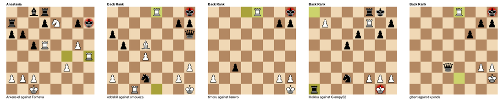

### About

- This report was compiled on 30 December 2021.
- These statistics are presented for general interest only. They are not guaranteed to be comprehensive, complete[^13], accurate, or up to date. They may be periodically revised to incorporate updates and bugfixes.
- Any player determined by Lichess to have violated their Terms of Service when this report was compiled should not appear in the detailed statistics.[^14]
- [Homepage](https://lichess4545stats.github.io/docs/) / [source code](https://github.com/rahulan-c/lichess4545-stats)
- Acknowledgements: [Noun Project](https://thenounproject.com/) for the award icons; [Simon Ilincev](https://simonilincev.com/) for chess_graph, which produces the openings sunburst plots.
[^1]: There are several reasons why a pairing might not end up being played, including scheduling difficulties, a lack of available replacements, or one of the players not showing up at the start time!
[^2]: The number of games played in this statistic can differ from the number of games played in the season, as it excludes games where the result of the pairing was later changed to a forfeit win or loss.
[^3]: Note that these performance ratings only account for account games played on a specific board, so they differ in this respect from the performance ratings published on the Lichess4545 rosters page.
[^4]: “Plus” score = played wins - played losses. Also, these season scores exclude any unplayed games, forfeit results or byes.
[^5]: A game’s total clock time is the sum of both players’ move times from move 2 onwards.
[^6]: For these statistics, a played opening line is termed a gambit if it arises from an opening or variation that’s commonly associated with one side sacrificing some material in the opening (in return for compensation) *and* the side that played the gambit actually sacrificed material in the game (for at least 5 consecutive half-moves before move 16). In particular, the list of gambit openings isn’t restricted to named gambits; it also includes for example the Marshall Attack in the Ruy Lopez, the Budapest Defence, and several variations of the Two Knights Defence in the Italian Game. However, this approach excludes games where a side decides to gambit material when *not* playing a traditionally gambit-associated opening. Yes, those should be considered gambits. But they’re not here.
[^7]: Qualifying “gambiteers” are ordered by number of gambit games played before percentage score.
[^8]: *Archbishop of Accuracy*: this is for the player with the lowest average centipawn loss (CPL) over all games. Note that this calculation isn’t based on Lichess’s ACPL figures. It excludes moves played in the first 10 moves of a game and moves with a centipawn loss < 150 in *decided* positions. These are considered to be positions with an evaluation greater than or equal to +300 centipawns for one side. All evaluation data is sourced from Lichess server analysis. To be eligible, players must have played at least five games in the season. *David Award*: the player whose opponents achieved the highest percentage score across the season, excluding games against the player. One’s opponents must have played over 20 games (against others) to qualify. Suggested by Tranzoo. *Egalitarian Award*: intended for the team whose players performed most similarly to each other. First, I compute all players’ *relative* performance ratings – the difference between their actual performance rating (using FIDE’s method) and their initial rating. Then I group all players by team, and give the award to the team with the lowest standard deviation across its players’ relative ratings. Suggested by Silkthewanderer. *Gambit Guru*: most gambits played while scoring above 50%. *MVP Award*: minimum 5 games played. *Rookie Award*: minimum 4 games played. *Saved by the Bell*: Excludes moves made in positions with an evaluation of under +300 centipawns from the mover’s perspective. Ordering is determined first by # moves played with under 5 seconds remaining, then by least time remaining in such conditions, then by worst eval faced. *Slingshot Specialist*: the player with the highest total rating gap between their opponents and themselves when only considering wins against opponents rated at least 50 rating points higher.︎
[^9]: The season performance ratings presented in this report may differ slightly from ratings published on the Lichess4545 website, but both calculations are based on FIDE’s preferred method, and both exclude unplayed games such as forfeit wins/losses and scheduling draws.
[^10]: Season ACPL here excludes the first 10 moves of a game, all zero-CPL moves played in zero-evaluation positions, and moves played in positions where one side has an advantage of +300 centipawns or greater *that aren’t mistakes or blunders*.
[^11]: I award “comeback points” for each game that a player won after their opponent had an advantage of at least 300 centipawns, according to Lichess’ server analysis. The scoring is rather simple. A win after suffering an evaluation disadvantage of more than 6 pawns earns 1 point. A win after being down by 3-6 pawns earns 0.7 points. A draw after being down more than 6 pawns earns 0.5 points. A draw after being down 3-6 pawns earns 0.3 points. Then the points are added up.
[^12]: Excludes moves made in positions where the mover had an objective advantage of +3 or greater. Players are first ordered by number of moves made with 5 or fewer seconds remaining, then by least time they had left (across all qualifying moves), and finally by the worst objective evaluation they faced (again across all moves).
[^13]: For example, this report excludes from its analysis all games of less than 5 plies (half-moves), games that ended in a disconnection or by “cheat detected”, games that were aborted, and games that started from a custom position.
[^14]: However, players who were banned from the Lichess4545 leagues after finishing a season in the top three places are still shown with a podium place in that season’s report.